# Régression simple - I

22/01/2026

## Informations Pratiques

## Enseignants

- Mathieu Even (chercheur, Inria)
  - mathieu.even@inria
  - Statistiques, Inférence causale, ML
- Amélie Vernay
  - amelie.vernay@umontpellier.fr

## Module

- Régression linéaire simple
  - Moindres carrés ordinaires
  - Cadre gaussien
- Régression linéaire multiple
  - Moindres carrés ordinaires
  - Cadre gaussien
- Validation et sélection de modèle
  - Analyse des résidus
  - Selection de variables
- Variables qualitatives
  - ANOVA

## Module

- Séances
  - CM : 21h
  - TD : 9h
  - TP : 12h
- Evaluation
  - 1/2 contrôle continu
  - 1/2 Examen final

## Ressources

- Polycopié de Arnaud Guyader  
  https://perso.lpsm.paris/~aguyader/files/teaching/Regression.pdf
- An Introduction to Statistical Learning,  
  G. James, D. Witten, T. Hastie and R. Tibshirani  
  https://statlearning.com/
- Moodle?

## GitHub ?

- Voulez vous les slides et quel moyen préférentiel pour les partager?

## Computational tools

## `R Markdown`

- Integrated in `RStudio` : https://rmarkdown.rstudio.com/
- `Markdown`
  - Mark up language
  - Easy to learn
  - Integrated with \(\LaTeX\)
  - Pdf, html, documents, slides, …
- `R Markdown`
  - Reproducible code
  - Include some `R` chunk

## `R Markdown`

The Maunga Whau (Mt Eden) volcano, Auckland, New Zealand

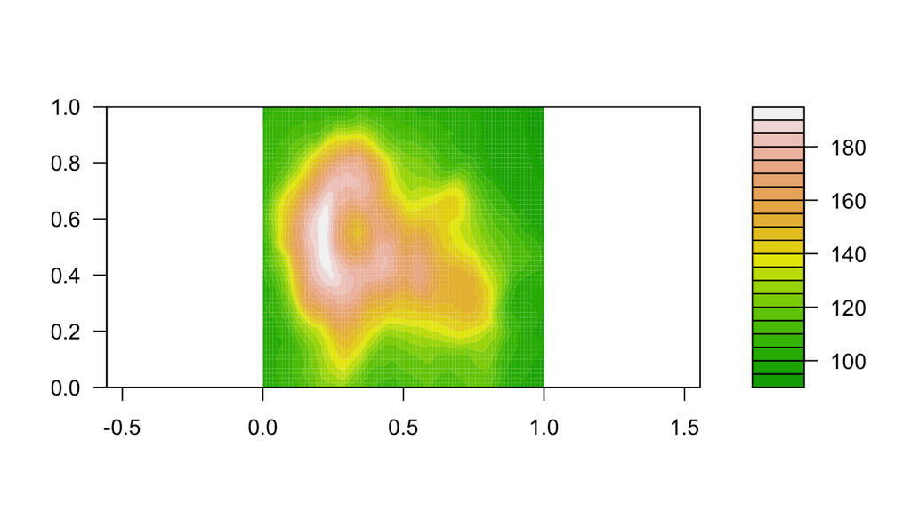

```r
filled.contour(volcano, color.palette = terrain.colors, asp = 1)
```

## Introduction

## Advertising Data

```r
library(here)
ad <- read.csv(here("data", "Advertising.csv"), row.names = "X")
head(ad)
```

```
##      TV radio newspaper sales
## 1 230.1  37.8      69.2  22.1
## 2  44.5  39.3      45.1  10.4
## 3  17.2  45.9      69.3   9.3
## 4 151.5  41.3      58.5  18.5
## 5 180.8  10.8      58.4  12.9
## 6   8.7  48.9      75.0   7.2
```

- `TV`, `radio`, `newspaper`: advertising budgets (thousands of $)
- `sales`: number of sales (thousands of units)

## Advertising Data

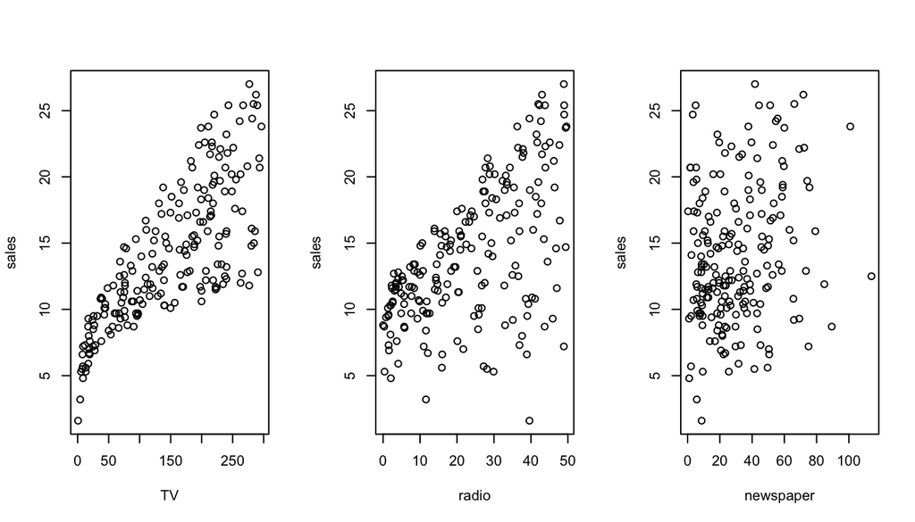

```r
attach(ad)
par(mfrow = c(1, 3))
plot(TV, sales); plot(radio, sales); plot(newspaper, sales)
```

## Advertising Data - Questions

- Is there a relationship between advertising budget and sale ?
- How strong is the relationship ?
- Which media contribute to sales ?
- How accurately can we estimate the effect of each medium ?
- How accurately can we predict future sales ?
- Is the relationship linear ?
- Is there synergy among the media ?

## Simple Linear Regression

## Advertising

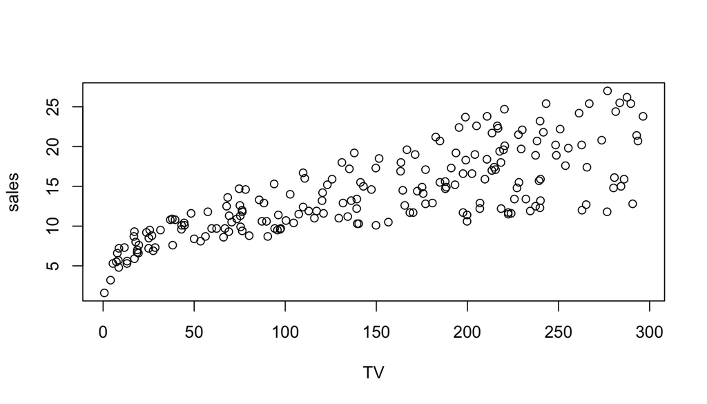

```r
plot(TV, sales)
```

## Setting

- \(1 \leq i \leq n\) repetitions of the experiment (markets, ind, …)
- \(y_i\): quantitative response for \(i\) (`sales`)
- \(x_i\): quantitative predicting variable for \(i\) (`TV`)

**Question**: Can we write ? \[ y_i \approx \beta_0 + \beta_1 x_i \]

- Approximately a linear relationship between \(y\) and \(x\) ?
- What does \(\approx\) means ?
- How do we find the “best” \(\beta_0\) and \(\beta_1\) ?
- How to interpret these coefficients?

## Which line ?

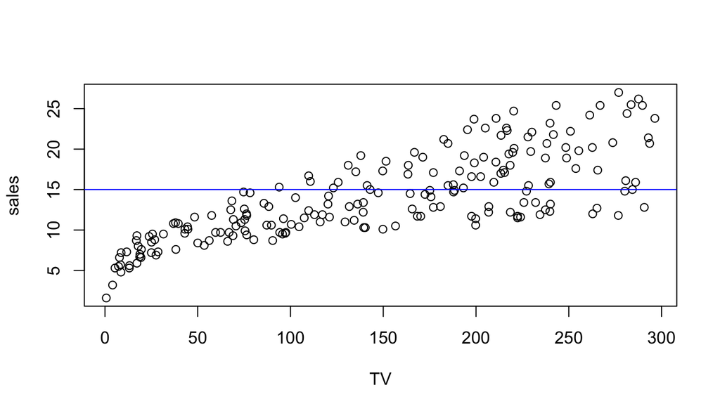

```r
plot(TV, sales)
abline(a = 15, b = 0, col = "blue")
```

## Which line ?

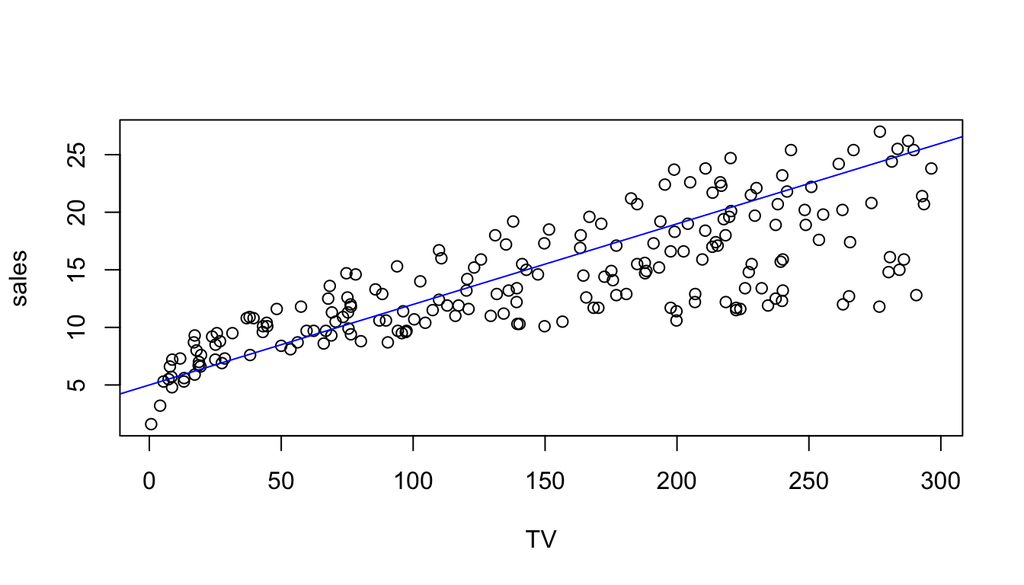

```r
plot(TV, sales)
abline(a = 5, b = 0.07, col = "blue")
```

## Which line ?

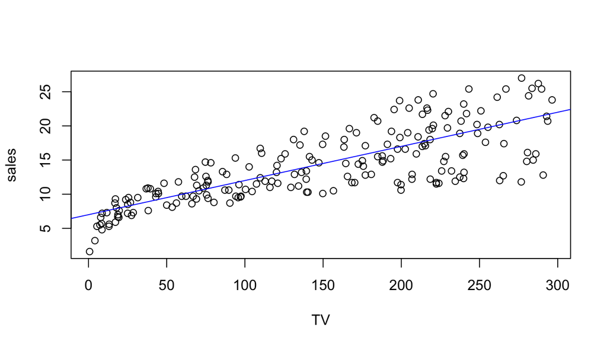

```r
plot(TV, sales)
abline(a = 7, b = 0.05, col = "blue")
```

## Model

\[y_i = \beta_0 + \beta_1 x_i + \epsilon_i, \quad \forall 1 \leq i \leq n\]

- \(y_i\): quantitative response for \(i\) (`sales`)
- \(x_i\): quantitative predicting variable for \(i\) (`TV`)
- \(\epsilon_i\): “error” for \(i\)
  - **random variable**
  - (H1) \(\mathbb{E}[\epsilon_i] = 0\) for all \(i\) (centered)
  - (H2) \(\mathbb{Var}[\epsilon_i] = \sigma^2\) for all \(i\) (identical variance)
  - (H3) \(\mathbb{Cov}[\epsilon_i; \epsilon_j] = 0\) for all \(i \neq j\) (independent)

## The Gaussian Setting (teaser for future lessons)

\[y_i = \beta_0 + \beta_1 x_i + \epsilon_i, \quad \forall 1 \leq i \leq n\]

## Model - Vectorial notation

\[ \begin{pmatrix} y_1 \\ \vdots \\ y_n \end{pmatrix} = \beta_0 \begin{pmatrix} 1 \\ \vdots \\ 1 \end{pmatrix} + \beta_1 \begin{pmatrix} x_1 \\ \vdots \\ x_n \end{pmatrix} + \begin{pmatrix} \epsilon_1 \\ \vdots \\ \epsilon_n \end{pmatrix} \]

- \(\mathbf{y} = (y_1, \dotsc, y_n)^T\) **random** vector of responses
- \(\mathbb{1} = (1, \dotsc, 1)^T\) vector of ones
- \(\mathbf{x} = (x_1, \dotsc, x_n)^T\) **non random** vector of predictors
- \(\boldsymbol{\epsilon} = (\epsilon_1, \dotsc, \epsilon_n)^T\) **random** vector of errors
- \(\beta_0\), \(\beta_1\) **non random, unknown** coefficients

\[\mathbf{y} = \beta_0 \mathbb{1} + \beta_1 \mathbf{x} + \boldsymbol{\epsilon}\]

## Ordinary Least Squares (OLS)

aka finding the best possible line

## OLS - Definition

The OLS estimators \(\hat{\beta}_0\) and \(\hat{\beta}_1\) are given by:

\[ (\hat{\beta}_0, \hat{\beta}_1) = \underset{(\beta_0, \beta_1) \in \mathbb{R}^2}{\operatorname{argmin}} \left\{ \sum_{i = 1}^n (y_i - \beta_0 - \beta_1 x_i)^2 \right\}\] \(~\)

**Goal**: Minimize the squared errors between:

- the prediction of the model \(\beta_0 + \beta_1 x_i\) and
- the actual observed value \(y_i\).

## Residual Sum of Squares

\[RSS(\beta_0,\beta_1) = \sum_{i = 1}^n (y_i - \beta_0 - \beta_1 x_i)^2\]

- Not standardized
- Quadratic, convex

## Advertising: bad line

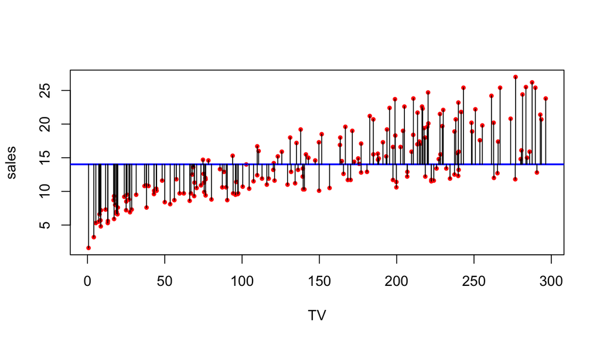

\[RSS = \sum_{i = 1}^n (y_i - \beta_0 - \beta_1 x_i)^2 = 5417.14875\]

## Advertising: another bad line

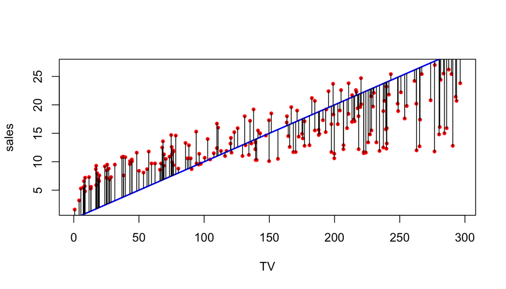

\[RSS = \sum_{i = 1}^n (y_i - \beta_0 - \beta_1 x_i)^2 = 6232.7659\]

## Advertising: OLS line

\[RSS = \sum_{i = 1}^n (y_i - \hat{\beta}_0 - \hat{\beta}_1 x_i)^2 = 2102.5305831\]

## OLS: Computation - 1/5

**Goal**: Minimize \(f(\beta_0, \beta_1) = \sum_{i = 1}^n (y_i - \beta_0 - \beta_1 x_i)^2\).

- Question: How can we minimize such a function in general?
- There is however a closed form solution here: how to compute it?

## OLS: Computation - 1/5

**Goal**: Minimize \(f(\beta_0, \beta_1) = \sum_{i = 1}^n (y_i - \beta_0 - \beta_1 x_i)^2\).

\[ \begin{aligned} \frac{\partial f(\hat{\beta}_0, \hat{\beta}_1)}{\partial \beta_0} &= \cdots &= 0 \\ \frac{\partial f(\hat{\beta}_0, \hat{\beta}_1)}{\partial \beta_1} &= \cdots &= 0 \\ \end{aligned} \]

## OLS: Computation - 2/5

**Goal**: Minimize \(f(\beta_0, \beta_1) = \sum_{i = 1}^n (y_i - \beta_0 - \beta_1 x_i)^2\).

\[ \begin{aligned} \frac{\partial f(\hat{\beta}_0, \hat{\beta}_1)}{\partial \beta_0} &= -2 \sum_{i = 1}^n (y_i - \hat{\beta}_0 - \hat{\beta}_1 x_i) &= 0 \\ \frac{\partial f(\hat{\beta}_0, \hat{\beta}_1)}{\partial \beta_1} &= -2 \sum_{i = 1}^n x_i(y_i - \hat{\beta}_0 - \hat{\beta}_1 x_i) &= 0 \\ \end{aligned} \]

## OLS: Computation - 3/5

First equation gives:

\[ \begin{aligned} 0 &= -2 \sum_{i = 1}^n (y_i - \hat{\beta}_0 - \hat{\beta}_1 x_i) \\ n \hat{\beta}_0 &= \sum_{i = 1}^n y_i - \hat{\beta}_1 \sum_{i = 1}^n x_i \\ \hat{\beta}_0 &= \bar{y} - \hat{\beta}_1 \bar{x} \\ \end{aligned} \]

## Advertising: Gravity Point

\[ \hat{\beta}_0 = \bar{y} - \hat{\beta}_1 \bar{x} \rightarrow \bar{y} = \hat{\beta}_0 + \hat{\beta}_1 \bar{x} \]

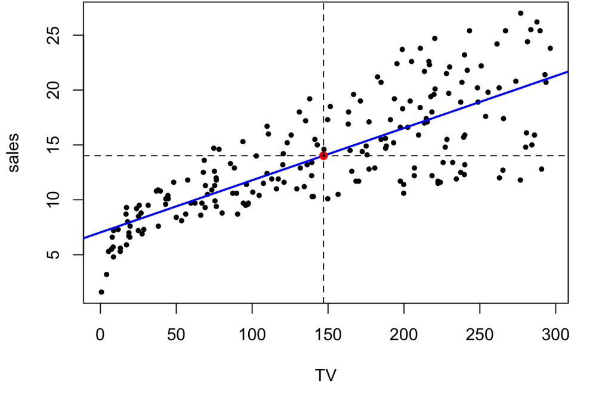

- OLS line goes through \((\bar{x}, \bar{y})\) the gravity point.

## OLS: Computation - 4/5

First equation gives:

\[ \begin{aligned} \hat{\beta}_0 &= \bar{y} - \hat{\beta}_1 \bar{x} \\ \end{aligned} \]

Second equation gives:

\[ \begin{aligned} -2 \sum_{i = 1}^n x_i(y_i - \hat{\beta}_0 - \hat{\beta}_1 x_i) &= 0 \\ \hat{\beta}_0 \sum_{i = 1}^n x_i + \hat{\beta}_1 \sum_{i = 1}^n x_i^2 &= \sum_{i = 1}^n x_iy_i \\ \hat{\beta}_1 \left(\sum_{i = 1}^n x_i^2 - \bar{x} \sum_{i = 1}^n x_i \right) &= - \bar{y}\sum_{i = 1}^n x_i + \sum_{i = 1}^n x_iy_i \\ \end{aligned} \]

## OLS: Computation - 5/5

First equation gives:

\[ \begin{aligned} \hat{\beta}_0 &= \bar{y} - \hat{\beta}_1 \bar{x} \\ \end{aligned} \]

Second equation gives:

\[ \begin{aligned} \hat{\beta}_1 &= \frac{ \sum_{i = 1}^n x_iy_i - \sum_{i = 1}^n x_i\bar{y}}{\sum_{i = 1}^n x_i^2 - \sum_{i = 1}^n x_i\bar{x}} = \frac{ \sum_{i = 1}^n x_i(y_i - \bar{y})}{\sum_{i = 1}^n x_i(x_i - \bar{x})} \\ \hat{\beta}_1 &= \frac{ \sum_{i = 1}^n (x_i - \bar{x})(y_i - \bar{y})}{\sum_{i = 1}^n (x_i -\bar{x})(x_i - \bar{x})} \\ \end{aligned} \]

because \[ \sum_{i = 1}^n (y_i - \bar{y}) = 0 = \sum_{i = 1}^n (x_i - \bar{x}) \]

## OLS: Expressions

\[ (\hat{\beta}_0, \hat{\beta}_1) = \underset{(\beta_0, \beta_1) \in \mathbb{R}^2}{\operatorname{argmin}} \left\{ \sum_{i = 1}^n (y_i - \beta_0 - \beta_1 x_i)^2 \right\} \]

Closed form expressions: \[ \hat{\beta}_1 = \frac{\sum_{i = 1}^n (x_i - \bar{x})(y_i - \bar{y})}{\sum_{i = 1}^n (x_i - \bar{x})^2} = \frac{s_{\mathbf{y},\mathbf{x}}^2}{s_{\mathbf{x}}^2} \qquad \hat{\beta}_0 = \bar{y} - \hat{\beta}_1\bar{x} \]

With \[ s_{\mathbf{x}}^2 = \frac{1}{n}\sum_{i = 1}^n (x_i - \bar{x})^2 \qquad s_{\mathbf{y},\mathbf{x}}^2 = \frac{1}{n}\sum_{i = 1}^n (x_i - \bar{x})(y_i - \bar{y}) \] the empirical variance and covariance of \(\mathbf{x}\) and \(\mathbf{y}\).

## Advertising: OLS line

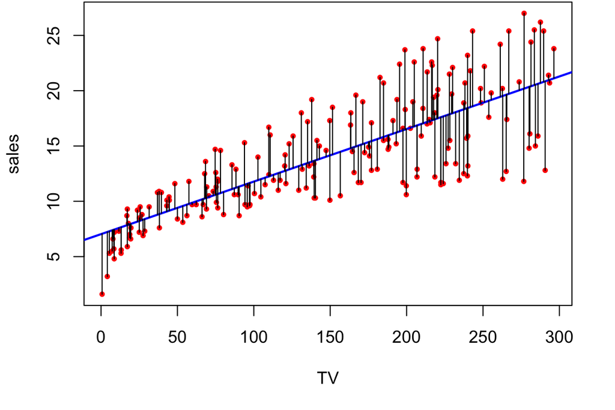

## OLS: Remarks

\[ \hat{\beta}_1 = \frac{\sum_{i = 1}^n (x_i - \bar{x})(y_i - \bar{y})}{\sum_{i = 1}^n (x_i - \bar{x})^2} \qquad \hat{\beta}_0 = \bar{y} - \hat{\beta}_1\bar{x} \]

- \(\hat{\beta}_0 + \hat{\beta}_1 \bar{x} = \bar{y}\)  
  The OLS regression line goes through the gravity point \((\bar{x}, \bar{y})\)
- \(\hat{\beta}_0\) and \(\hat{\beta}_1\) are **linear** in the data \(\mathbf{y} = (y_1, \cdots, y_n)^T\).
- \(\hat{\beta}_1 = \frac{s_{\mathbf{y},\mathbf{x}}^2}{s_{\mathbf{x}}^2}\).

## OLS estimators are unbiased

## Simulated dataset - Model

Simulate according to the model : \[\mathbf{y} = 2 \cdot \mathbb{1} + 3 \cdot \mathbf{x} + \boldsymbol{\epsilon}\]

```r
## Set the seed (Quia Sapientia)
set.seed(12890926)
## Number of samples
n <- 100
## vector of x
x_test <- runif(n, -2, 2)
## coefficients
beta_0 <- 2; beta_1 <- 3
## epsilon
error_test <- rnorm(n, mean = 0, sd = 10)
## y = 2 + 3 * x + epsilon
y_test <- beta_0 + beta_1 * x_test + error_test
```

## Simulated dataset - OLS

Find the OLS regression line:

\[ \hat{\beta}_1 = \frac{s_{\mathbf{y},\mathbf{x}}^2}{s_{\mathbf{x}}^2} \qquad \hat{\beta}_0 = \bar{y} - \hat{\beta}_1\bar{x} \]

```r
beta_hat_1 <- var(y_test, x_test) / var(x_test)
beta_hat_0 <- mean(y_test) - beta_hat_1 * mean(x_test)
```

## Simulated dataset - Plot

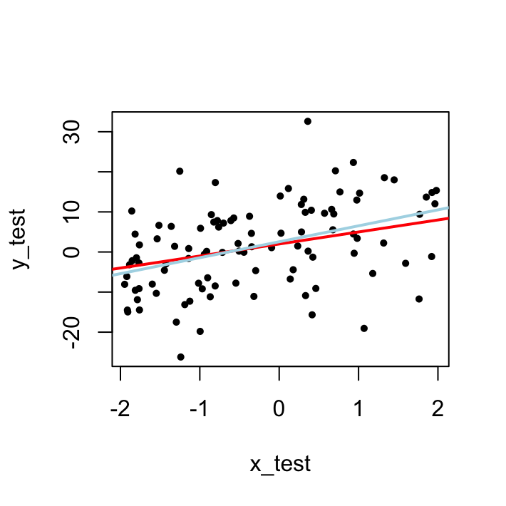

```r
## Dataset
plot(x_test, y_test, pch = 16, cex = 0.7)
## Ideal line
abline(a = beta_0, b = beta_1, col = "red", lwd = 2)
## Regression line
abline(a = beta_hat_0, b = beta_hat_1, col = "lightblue", lwd = 2)
```

## Simulated dataset : replicates

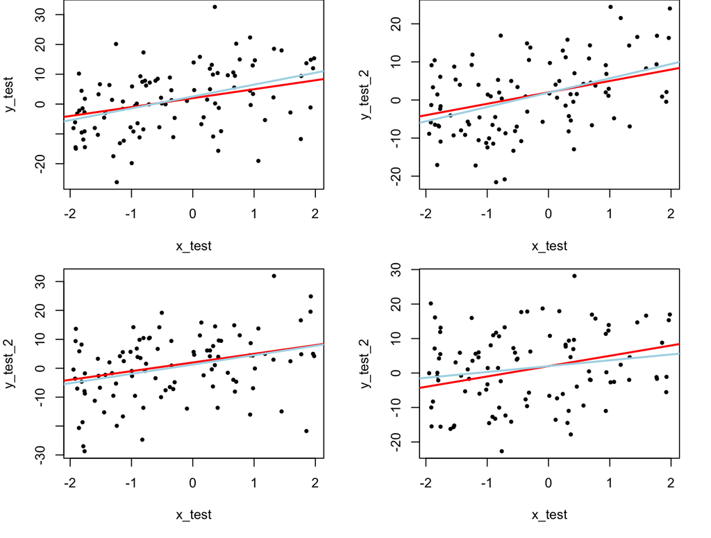

## Simulated dataset : replicates

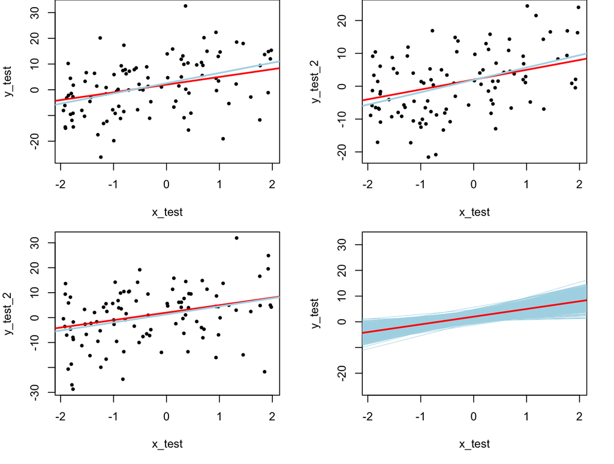

## Simulated dataset : empirical mean

\(~\)

- The OLS estimators are **unbiased** \[ \mathbb{E}[\hat{\beta}_0] = \beta_0 \qquad \mathbb{E}[\hat{\beta}_1] = \beta_1 \]

## The OLS estimators are unbiased

\[ \mathbb{E}[\hat{\beta}_0] = \beta_0 \qquad \mathbb{E}[\hat{\beta}_1] = \beta_1 \]

Valid as long as residuals:

- are **centered** \(\to\) (H1): \(\mathbb{E}[\epsilon_i] = 0\)

## OLS is unbiased - Proof 1/4

\[ \mathbb{E}[\hat{\beta}_1] = \mathbb{E}\left[\frac{\sum_{i = 1}^n (x_i - \bar{x})(y_i - \bar{y})}{\sum_{i = 1}^n (x_i - \bar{x})^2}\right] = \cdots \\ \]

## OLS is unbiased - Proof 2/4

\[ \mathbb{E}[\hat{\beta}_1] = \mathbb{E}\left[\frac{\sum_{i = 1}^n (x_i - \bar{x})(y_i - \bar{y})}{\sum_{i = 1}^n (x_i - \bar{x})^2}\right] = \frac{\sum_{i = 1}^n (x_i - \bar{x})\mathbb{E}[(y_i - \bar{y})]}{\sum_{i = 1}^n (x_i - \bar{x})^2} \\ \]

According to our model: \[y_i = \beta_0 + \beta_1 x_i + \epsilon_i \quad \& \quad \mathbb{E}[\epsilon_i] = 0\]

so: \[ \mathbb{E}[y_i] = \beta_0 + \beta_1 x_i \\ \mathbb{E}[y_i - \bar{y}] = \beta_0 + \beta_1 x_i - (\beta_0 + \beta_1 \bar{x}) = \beta_1(x_i - \bar{x}) \]

and: \[ \mathbb{E}[\hat{\beta}_1] = \frac{\sum_{i = 1}^n (x_i - \bar{x})\beta_1(x_i - \bar{x})}{\sum_{i = 1}^n (x_i - \bar{x})^2} = \beta_1 \]

## OLS is unbiased - Proof 3/4

\[ \begin{aligned} \mathbb{E}[\hat{\beta}_0] &= \mathbb{E}\left[\bar{y} - \hat{\beta}_1\bar{x}\right]\\ &= \cdots \end{aligned} \]

## OLS is unbiased - Proof 4/4

\[ \begin{aligned} \mathbb{E}[\hat{\beta}_0] &= \mathbb{E}\left[\bar{y} - \hat{\beta}_1\bar{x}\right]\\ &= \mathbb{E}[\bar{y}] - \mathbb{E}[\hat{\beta}_1]\bar{x}\\ &= \beta_0 + \beta_1 \bar{x} - \beta_1 \bar{x}\\ &= \beta_0 \end{aligned} \]

## OLS Estimators: Remark

\[ \begin{aligned} \hat{\beta}_1 &= \frac{1}{n s_{\mathbf{x}}^2}\sum_{i = 1}^n (x_i - \bar{x})(y_i - \bar{y})\\ &= \frac{1}{n s_{\mathbf{x}}^2}\sum_{i = 1}^n (x_i - \bar{x})(\beta_0 + \beta_1x_i + \epsilon_i - [\beta_0 + \beta_1\bar{x}+\overline{\epsilon}])\\ &= \beta_1 + \frac{1}{n s_{\mathbf{x}}^2} \sum_{i = 1}^n (x_i - \bar{x})\epsilon_i \end{aligned} \]

This expression is theoretical, but it makes it easy to prove \[\mathbb{E}[\hat{\beta}_1] = \beta_1.\]

## Variance of the OLS estimators

## OLS Estimators: Variances

\[ \mathbb{Var}[\hat{\beta}_0] = \frac{\sigma^2}{n} \left( 1 + \frac{\bar{x}^2}{s_{\mathbf{x}}^2} \right) \]

\[ \mathbb{Var}[\hat{\beta}_1] = \frac{\sigma^2}{n}\frac{1}{s_{\mathbf{x}}^2} \]

Valid as long as residuals:

- are **centered** \(\to\) (H1): \(\mathbb{E}[\epsilon_i] = 0\)
- have **identical variance** \(\to\) (H2): \(\mathbb{Var}[\epsilon_i] = \sigma^2\)
- are **independent** \(\to\) (H3): \(\mathbb{Cov}[\epsilon_i; \epsilon_j] = 0\)

## OLS Estimators: Variances - Proof 1/6

\[ \begin{aligned} \mathbb{Var}[\hat{\beta}_1] &= \mathbb{Var}\left[\beta_1 + \frac{1}{n s_{\mathbf{x}}^2} \sum_{i = 1}^n (x_i - \bar{x})\epsilon_i\right] \\ &= \cdots \end{aligned} \]

## OLS Estimators: Variances - Proof 2/6

\[ \begin{aligned} \mathbb{Var}[\hat{\beta}_1] &= \mathbb{Var}\left[\beta_1 + \frac{1}{n s_{\mathbf{x}}^2} \sum_{i = 1}^n (x_i - \bar{x})\epsilon_i\right] \\ &= \frac{1}{(n s_{\mathbf{x}}^2)^2} \sum_{i = 1}^n (x_i - \bar{x})^2\mathbb{Var}[\epsilon_i] & [H3]\\ &= \frac{n s_{\mathbf{x}}^2}{(n s_{\mathbf{x}}^2)^2} \sigma^2 & [H2] \\ &= \frac{\sigma^2}{n s_{\mathbf{x}}^2} \end{aligned} \]

## OLS Estimators: Variances - Proof 3/6

\[ \begin{aligned} \mathbb{Var}[\hat{\beta}_0] &= \mathbb{Var}[\bar{y} - \hat{\beta}_1\bar{x}] = \cdots \end{aligned} \]

**Attention** \(\bar{y}\) and \(\hat{\beta}_1\) might be correlated (they have the same \(\epsilon_i\))

\[ \begin{aligned} \mathbb{Cov}[\bar{y}; \hat{\beta}_1] &= \cdots \end{aligned} \]

## OLS Estimators: Variances - Proof 4/6

\[ \begin{aligned} \mathbb{Cov}[\bar{y}; \hat{\beta}_1] &= \mathbb{Cov}\left[\beta_0 + \beta_1\bar{x} + \bar{\epsilon}; \beta_1 + \frac{1}{n s_{\mathbf{x}}^2} \sum_{i = 1}^n (x_i - \bar{x})\epsilon_i\right] \\ &= \cdots \end{aligned} \]

## OLS Estimators: Variances - Proof 4/6

\[ \begin{aligned} \mathbb{Cov}[\bar{y}; \hat{\beta}_1] &= \mathbb{Cov}\left[\beta_0 + \beta_1\bar{x} + \bar{\epsilon}; \beta_1 + \frac{1}{n s_{\mathbf{x}}^2} \sum_{i = 1}^n (x_i - \bar{x})\epsilon_i\right] \\ &= \mathbb{Cov}\left[\frac{1}{n}\sum_{i = 1}^n\epsilon_i; \frac{1}{n s_{\mathbf{x}}^2} \sum_{i = 1}^n (x_i - \bar{x})\epsilon_i\right] \\ &= \frac{1}{n^2 s_{\mathbf{x}}^2} \sum_{i = 1}^n \sum_{j = 1}^n \mathbb{Cov}\left[\epsilon_i; (x_j - \bar{x})\epsilon_j\right] \\ &= \frac{1}{n^2 s_{\mathbf{x}}^2} \sum_{i = 1}^n \mathbb{Cov}\left[\epsilon_i; (x_i - \bar{x})\epsilon_i\right] \\ &= \frac{1}{n^2 s_{\mathbf{x}}^2} \sum_{i = 1}^n (x_i - \bar{x}) \sigma^2 = 0 \end{aligned} \]

## OLS Estimators: Variances - Proof 5/6

Since \(\mathbb{Cov}[\bar{y}; \hat{\beta}_1] = 0\) :

\[ \begin{aligned} \mathbb{Var}[\hat{\beta}_0] &= \mathbb{Var}[\bar{y} - \hat{\beta}_1\bar{x}] = \mathbb{Var}[\bar{y}] + \mathbb{Var}[\hat{\beta}_1\bar{x}]\\ &= \cdots \end{aligned} \]

## OLS Estimators: Variances - Proof 6/6

Since \(\mathbb{Cov}[\bar{y}; \hat{\beta}_1] = 0\) :

\[ \begin{aligned} \mathbb{Var}[\hat{\beta}_0] &= \mathbb{Var}[\bar{y} - \hat{\beta}_1\bar{x}] = \mathbb{Var}[\bar{y}] + \mathbb{Var}[\hat{\beta}_1\bar{x}]\\ &= \frac{1}{n^2}\mathbb{Var}\left[\sum_{i=1}^n\epsilon_i\right] + \bar{x}^2\mathbb{Var}[\hat{\beta}_1]\\ &= \frac{1}{n}\sigma^2 + \frac{\bar{x}^2 \sigma^2}{n s_{\mathbf{x}}^2} \\ &= \frac{\sigma^2}{n} \left(1 + \frac{\bar{x}^2}{s_{\mathbf{x}}^2}\right) \end{aligned} \]

## OLS Estimators: Covariance

\[ \mathbb{Cov}[\hat{\beta}_0; \hat{\beta}_1] = - \frac{\sigma^2}{n} \frac{\bar{x}}{s_{\mathbf{x}}^2} \]

Valid as long as residuals:

- are **centered** \(\to\) (H1): \(\mathbb{E}[\epsilon_i] = 0\)
- have **identical variance** \(\to\) (H2): \(\mathbb{Var}[\epsilon_i] = \sigma^2\)
- are **independent** \(\to\) (H3): \(\mathbb{Cov}[\epsilon_i; \epsilon_j] = 0\)

## OLS Estimators: Covariance - Proof 1/2

\[ \begin{aligned} \mathbb{Cov}[\hat{\beta}_0; \hat{\beta}_1] & = \mathbb{Cov}[\bar{y} - \hat{\beta}_1\bar{x}; \hat{\beta}_1] = \cdots \end{aligned} \]

## OLS Estimators: Covariance - Proof 2/2

\[ \begin{aligned} \mathbb{Cov}[\hat{\beta}_0; \hat{\beta}_1] &= \mathbb{Cov}[\bar{y} - \hat{\beta}_1\bar{x}; \hat{\beta}_1]\\ &= \mathbb{Cov}[\bar{y}; \hat{\beta}_1] - \bar{x}\mathbb{Cov}[\hat{\beta}_1; \hat{\beta}_1]\\ &= 0 - \bar{x}\frac{\sigma^2}{n s_{\mathbf{x}}^2}\\ &= - \frac{\sigma^2 \bar{x}}{n s_{\mathbf{x}}^2} \end{aligned} \]

## OLS Estimators: Variances - Remarks

- \(\mathbb{Var}[\hat{\beta}_1] = \frac{\sigma^2}{n}\frac{1}{s_{\mathbf{x}}^2} = \frac{\sigma^2}{\sum(x_i - \bar{x})^2}\)  
  \(\to\) if the \(x_i\) are more spread out, \(\mathbb{Var}[\hat{\beta}_1]\) is smaller  
  \(\to\) we have more *leverage* to estimate the slope
- \(\hat{\beta}_0 = \bar{y} - \hat{\beta}_1\bar{x}\) and \(\mathbb{Var}[\hat{\beta}_0] = \frac{\sigma^2}{n} \left( 1 + \frac{\bar{x}^2}{s_{\mathbf{x}}^2} \right)\)  
  \(\to\) if \(\bar{x} = 0\), then \(\hat{\beta}_0 = \bar{y}\) and \(\mathbb{Var}[\hat{\beta}_0] = \frac{\sigma^2}{n}\)  
  \(\to\) we find the estimator of the population expectation of \(y\).
- \(\hat{\beta}_0 = \bar{y} - \hat{\beta}_1\bar{x}\)  
  \(\to\) assume \((\bar{x}, \bar{y})\) is fixed and \(\bar{x} \geq 0\)  
  \(\to\) then when \(\hat{\beta}_1\) increases, \(\hat{\beta}_0\) decreases  
  \(\to\) \(\mathbb{Cov}[\hat{\beta}_0; \hat{\beta}_1] \leq 0\)

## OLS Estimators: Variances - Remarks

\[ \mathbb{Var}[\hat{\beta}_0] = \frac{\sigma^2}{n} \left( 1 + \frac{\bar{x}^2}{s_{\mathbf{x}}^2} \right) \quad \mathbb{Var}[\hat{\beta}_1] = \frac{\sigma^2}{n}\frac{1}{s_{\mathbf{x}}^2} \]

\[ \mathbb{Cov}[\hat{\beta}_0; \hat{\beta}_1] = - \frac{\sigma^2}{n} \frac{\bar{x}}{s_{\mathbf{x}}^2} \]

- If \(s_{\mathbf{x}}^2\) is constant, then the variances decrease as \(1/n\).

## Gauss Markov Theorem

## Gauss Markov Theorem

The OLS estimator is the **BLUE**  
(Best Linear Unbiased Estimator):  
Among all unbiased estimators that are linear in \(\mathbf{y}\), the OLS estimators are the ones that have the smallest variance.

## Gauss Markov Theorem - Proof 1/8

\[ \hat{\beta}_1 = \sum_{i = 1}^n p_i y_i \quad \text{ with } \quad p_i = \frac{x_i - \bar{x}}{n s_{\mathbf{x}}^2} \]

- Let \(\tilde{\beta}_1\) be another linear unbiased estimator.
- \(\tilde{\beta}_1\) is linear: \(\tilde{\beta}_1 = \sum_{i = 1}^n q_i y_i\)
- Let’s show that \(\sum_{i=1}^n q_i = 0\) and \(\sum_{i=1}^n q_ix_i = 1\)

## Gauss Markov Theorem - Proof 2/8

- Let’s show that \(\sum_{i=1}^n q_i = 0\) and \(\sum_{i=1}^n q_ix_i = 1\)

\[ \begin{aligned} \mathbb{E}[\tilde{\beta}_1] &= \mathbb{E}\left[\sum_{i = 1}^n q_i y_i\right] = \cdots = \beta_1 & \text{(unbiased)} \end{aligned} \]

## Gauss Markov Theorem - Proof 3/8

\[ \begin{aligned} \mathbb{E}[\tilde{\beta}_1] &= \sum_{i = 1}^n \mathbb{E}[q_i y_i] \\ &= \sum_{i = 1}^n \mathbb{E}[q_i (\beta_0 + \beta_1 x_i + \epsilon_i)] \\ \beta_1 &= \beta_0 \sum_{i = 1}^n q_i + \beta_1 \sum_{i = 1}^n q_ix_i & \text{(unbiased)} \end{aligned} \]

- This is true for any \(\beta_0\), \(\beta_1\)  
  \(\to\) \(\sum_{i=1}^n q_i = 0\) and \(\sum_{i=1}^n q_ix_i = 1\)

## Gauss Markov Theorem - Proof 4/8

\[ \hat{\beta}_1 = \sum_{i = 1}^n p_i y_i \quad \text{ with } \quad p_i = \frac{x_i - \bar{x}}{n s_{\mathbf{x}}^2} \]

- Let \(\tilde{\beta}_1\) be another linear unbiased estimator.
- \(\tilde{\beta}_1\) is linear: \(\tilde{\beta}_1 = \sum_{i = 1}^n q_i y_i\)
- We have \(\sum_{i=1}^n q_i = 0\) and \(\sum_{i=1}^n q_ix_i = 1\)
- Let’s show that \(\mathbb{Var}[\tilde{\beta}_1] \geq \mathbb{Var}[\hat{\beta}_1]\)

## Gauss Markov Theorem - Proof 5/8

- Let’s show that \(\mathbb{Var}[\tilde{\beta}_1] \geq \mathbb{Var}[\hat{\beta}_1]\) \[ \begin{aligned} \mathbb{Var}[\tilde{\beta}_1] &= \mathbb{Var}[\tilde{\beta}_1 - \hat{\beta}_1 + \hat{\beta}_1]\\ &= \cdots \end{aligned} \]

## Gauss Markov Theorem - Proof 6/8

- Let’s show that \(\mathbb{Var}[\tilde{\beta}_1] \geq \mathbb{Var}[\hat{\beta}_1]\) \[ \begin{aligned} \mathbb{Var}[\tilde{\beta}_1] &= \mathbb{Var}[\tilde{\beta}_1 - \hat{\beta}_1 + \hat{\beta}_1]\\ &= \mathbb{Var}[\tilde{\beta}_1 - \hat{\beta}_1] + \mathbb{Var}[\hat{\beta}_1] + 2\mathbb{Cov}[\tilde{\beta}_1 - \hat{\beta}_1; \hat{\beta}_1] \end{aligned} \]

\[ \begin{aligned} \mathbb{Cov}[\tilde{\beta}_1 - \hat{\beta}_1; \hat{\beta}_1] &= \mathbb{Cov}[\tilde{\beta}_1; \hat{\beta}_1] - \mathbb{Var}[\hat{\beta}_1] \\ &= \cdots \end{aligned} \]

## Gauss Markov Theorem - Proof 7/8

- Let’s show that \(\mathbb{Var}[\tilde{\beta}_1] \geq \mathbb{Var}[\hat{\beta}_1]\) \[ \begin{aligned} \mathbb{Var}[\tilde{\beta}_1] &= \mathbb{Var}[\tilde{\beta}_1 - \hat{\beta}_1 + \hat{\beta}_1]\\ &= \mathbb{Var}[\tilde{\beta}_1 - \hat{\beta}_1] + \mathbb{Var}[\hat{\beta}_1] + 2\mathbb{Cov}[\tilde{\beta}_1 - \hat{\beta}_1; \hat{\beta}_1] \end{aligned} \]

\[ \begin{aligned} \mathbb{Cov}[\tilde{\beta}_1 - \hat{\beta}_1; \hat{\beta}_1] &= \mathbb{Cov}[\tilde{\beta}_1; \hat{\beta}_1] - \mathbb{Var}[\hat{\beta}_1] \\ &= \sum_{i=1}^n p_i q_i \sigma^2 - \frac{\sigma^2}{n s_{\mathbf{x}}^2} \\ &=\frac{\sigma^2}{n s_{\mathbf{x}}^2}\left(\sum_{i=1}^nq_ix_i - \sum_{i=1}^nq_i\bar{x} - 1\right) \\ &= 0 \end{aligned} \]

## Gauss Markov Theorem - Proof 8/8

- Let’s show that \(\mathbb{Var}[\tilde{\beta}_1] \geq \mathbb{Var}[\hat{\beta}_1]\) \[ \begin{aligned} \mathbb{Var}[\tilde{\beta}_1] &= \mathbb{Var}[\tilde{\beta}_1 - \hat{\beta}_1 + \hat{\beta}_1]\\ &= \mathbb{Var}[\tilde{\beta}_1 - \hat{\beta}_1] + \mathbb{Var}[\hat{\beta}_1] + 2\mathbb{Cov}[\tilde{\beta}_1 - \hat{\beta}_1; \hat{\beta}_1] \\ &= \mathbb{Var}[\tilde{\beta}_1 - \hat{\beta}_1] + \mathbb{Var}[\hat{\beta}_1] \end{aligned} \]
- But \(\mathbb{Var}[\tilde{\beta}_1 - \hat{\beta}_1] \geq 0\) (variance) \(\to\) \(\mathbb{Var}[\tilde{\beta}_1] \geq \mathbb{Var}[\hat{\beta}_1]\)
- Same for \(\hat{\beta}_0\).

## Variance estimation

## Residuals

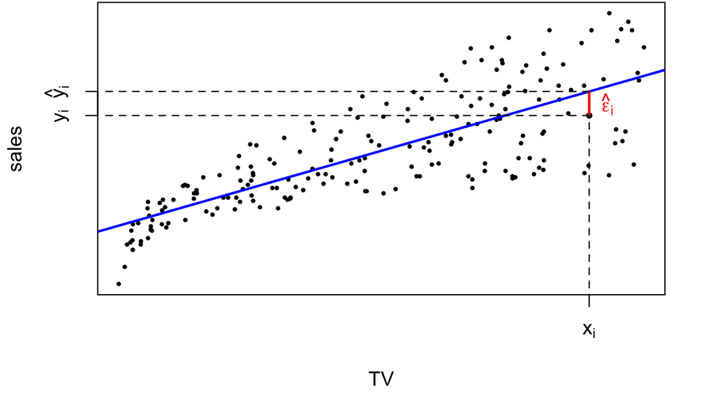

- \(\hat{y}_i = \hat{\beta}_0 + \hat{\beta}_1x_i\)
- \(\hat{\epsilon}_i = y_i - \hat{y}_i\)

## Residuals

- By construction, the sum of residuals is null.

\[ \begin{aligned} \sum_{i = 1}^n \hat{\epsilon}_i &= \sum_{i = 1}^n y_i - \hat{y}_i \\ &= \cdots \\ &= 0 \end{aligned} \]

## Residuals

- By construction, the sum of residuals is null.

\[ \begin{aligned} \sum_{i = 1}^n \hat{\epsilon}_i &= \sum_{i = 1}^n y_i - \hat{y}_i\\ &= \sum_{i = 1}^n y_i - \hat{\beta}_0 - \hat{\beta}_1 x_i & [\hat{\beta}_0 = \bar{y} - \hat{\beta}_1\bar{x}]\\ &= \sum_{i = 1}^n (y_i - \bar{y}) - \hat{\beta}_1(x_i - \bar{x}) \\ &= 0 \end{aligned} \]

## Unbiased Variance Estimator

\[ \hat{\sigma}^2 = \frac{1}{n-2} \sum_{i = 1}^n \hat{\epsilon}_i^2 = \frac{1}{n-2} \cdot RSS \]

is an unbiased estimator of the variance \(\sigma^2\).

- **Note**: `2` parameters \((\beta_0, \beta_1) \to n-\) `2`
- RSS is the Residual Sum of Squares

## Advertising

\[ \hat{\sigma}^2 = \frac{1}{n-2} \cdot RSS = \frac{1}{n-2} \sum_{i = 1}^n (y_i - \hat{\beta}_0 - \hat{\beta}_1 x_i)^2 = 10.62 \]

## Unbiased Var Estimator - Proof 1/4

\[ \begin{aligned} \mathbb{E}\left[\sum_{i=1}^n\hat{\epsilon}_i^2\right] &= \sum_{i=1}^n\mathbb{E}\left[\hat{\epsilon}_i^2\right] = \sum_{i=1}^n\mathbb{Var}\left[\hat{\epsilon}_i\right] \end{aligned} \]

\(~\)

\[ \begin{aligned} \mathbb{Var}[\hat{\epsilon}_i] &= \mathbb{Var}[y_i - \hat{y}_i] \\ &= \mathbb{Var}[\beta_0 + \beta_1 x_i + \epsilon_i - \hat{\beta}_0 - \hat{\beta}_1 x_i]\\ &= \cdots \end{aligned} \]

## Unbiased Var Estimator - Proof 2/4

\[ \begin{aligned} \mathbb{Var}[\hat{\epsilon}_i] &= \mathbb{Var}[y_i - \hat{y}_i] \\ &= \mathbb{Var}[\beta_0 + \beta_1 x_i + \epsilon_i - \hat{\beta}_0 - \hat{\beta}_1 x_i]\\ &= \mathbb{Var}[\epsilon_i - \hat{\beta}_0 - \hat{\beta}_1 x_i]\\ &= \mathbb{Var}[\epsilon_i] + \mathbb{Var}[\hat{\beta}_0 + \hat{\beta}_1 x_i] - 2\mathbb{Cov}[\epsilon_i; \hat{\beta}_0 + \hat{\beta}_1 x_i] \end{aligned} \]

## Unbiased Var Estimator - Proof 3/4

\[ \begin{aligned} \mathbb{Var}[\hat{\epsilon}_i] &= \mathbb{Var}[\epsilon_i] + \mathbb{Var}[\hat{\beta}_0 + \hat{\beta}_1 x_i] - 2\mathbb{Cov}[\epsilon_i; \hat{\beta}_0 + \hat{\beta}_1 x_i] \end{aligned} \] \(~\)

\[ \begin{aligned} \mathbb{Var}[\hat{\beta}_0 + \hat{\beta}_1 x_i] &= \mathbb{Var}[\bar{y} + \hat{\beta}_1 (x_i - \bar{x})] \qquad~~ \{\hat{\beta}_0 = \bar{y} - \hat{\beta}_1 \bar{x}\}\\ &= \mathbb{Var}[\bar{y}] + \mathbb{Var}[\hat{\beta}_1 (x_i - \bar{x})] ~~ \{\mathbb{Cov}[\bar{y},\hat{\beta}_1] = 0\}\\ &= \frac{\sigma^2}{n} + (x_i - \bar{x})^2\frac{\sigma^2}{n}\frac{1}{s_{\mathbf{x}}^2} \end{aligned} \] \(~\)

\[ \begin{aligned} \mathbb{Cov}[\hat{\beta}_0 + \hat{\beta}_1 x_i; \epsilon_i] &= \mathbb{Cov}[\bar{y}; \epsilon_i] + \mathbb{Cov}[\hat{\beta}_1 (x_i - \bar{x}); \epsilon_i]\\ &= \frac{\sigma^2}{n} + (x_i - \bar{x})\frac{1}{ns_{\mathbf{x}}^2}(x_i - \bar{x})\sigma^2 \end{aligned} \]

## Unbiased Var Estimator - Proof 4/4

\[ \begin{aligned} \mathbb{Var}[\hat{\epsilon}_i] &= \mathbb{Var}[\epsilon_i] + \mathbb{Var}[\hat{\beta}_0 + \hat{\beta}_1 x_i] - 2\mathbb{Cov}[\epsilon_i; \hat{\beta}_0 + \hat{\beta}_1 x_i]\\ &= \sigma^2 - \frac{\sigma^2}{n} - \frac{\sigma^2 (x_i - \bar{x})^2}{ns_{\mathbf{x}}^2} \end{aligned} \]

\[ \begin{aligned} \mathbb{E}\left[\sum_{i=1}^n\hat{\epsilon}_i^2\right] &= \sum_{i=1}^n\mathbb{Var}\left[\hat{\epsilon}_i\right] = \sum_{i=1}^n \left(\sigma^2 - \frac{\sigma^2}{n} - \frac{\sigma^2 (x_i - \bar{x})^2}{ns_{\mathbf{x}}^2}\right)\\ &= n\sigma^2 - \sigma^2 - \sigma^2 = (n-2)\sigma^2 \end{aligned} \]

\(~\)

\[ \mathbb{E}\left[\hat{\sigma}^2\right] = \mathbb{E}\left[\frac{1}{n-2}\sum_{i=1}^n\hat{\epsilon}_i^2\right] = \sigma^2 \]

## Prediction

## Predict a new point

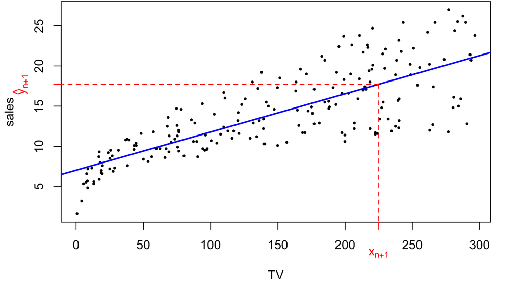

- **Question**: I spend \(x_{n+1}\) dollars on TV in a new market.  
  How many units will I sell ?

## Predict a new point

- We fitted \(\hat{\beta}_0\) and \(\hat{\beta}_1\) on \(((y_1, x_1), \dotsc, (y_n, x_n))\)
- A new point \(x_{n+1}\) comes along. How can we guess \(y_{n+1}\) ?
- We use the same model: \[ y_{n+1} = \beta_0 + \beta_1 x_{n+1} + \epsilon_{n+1} \] with \(\mathbb{E}[\epsilon_{n+1}] = 0\), \(\mathbb{Var}[\epsilon_{n+1}] = \sigma^2\) and \(\mathbb{Cov}[\epsilon_{n+1}; \epsilon_i] = 0\).
- We predict \(y_{n+1}\) with: \[ \hat{y}_{n+1} = \hat{\beta}_0 + \hat{\beta}_1 x_{n+1} \]
- **Question**: What is the error \(\hat{\epsilon}_{n+1} = y_{n+1} - \hat{y}_{n+1}\) ?

## Prediction Error

The prediction error \(\hat{\epsilon}_{n+1} = y_{n+1} - \hat{y}_{n+1}\) is such that: \[ \begin{aligned} \mathbb{E}[\hat{\epsilon}_{n+1}] &= 0\\ \mathbb{Var}[\hat{\epsilon}_{n+1}] &= \sigma^2 \left(1 + \frac{1}{n} + \frac{1}{ns_{\mathbf{x}}^2} (x_{n+1} - \bar{x})^2\right)\\ \end{aligned} \]

## Prediction Error - Proof 1/2

\[ \begin{aligned} \mathbb{E}[\hat{\epsilon}_{n+1}] &= \mathbb{E}[y_{n+1} - \hat{\beta}_0 - \hat{\beta}_1 x_{n+1}]\\ &= \cdots \end{aligned} \]

\[ \begin{aligned} \mathbb{E}[\hat{\epsilon}_{n+1}] &= \mathbb{E}[y_{n+1} - \hat{\beta}_0 - \hat{\beta}_1 x_{n+1}]\\ &= \mathbb{E}[y_{n+1}] - \mathbb{E}[\hat{\beta}_0] - \mathbb{E}[\hat{\beta}_1] x_{n+1}\\ &= \beta_0 + \beta_1 x_{n+1} - \beta_0 - \beta_1 x_{n+1} \\ &= 0 \end{aligned} \]

## Prediction Error - Proof 2/2

Because \(\hat{y}_{n+1}\) *does not depend* on \(\epsilon_{n+1}\):

\[ \begin{aligned} \mathbb{Var}[\hat{\epsilon}_{n+1}] &= \mathbb{Var}[y_{n+1} - \hat{y}_{n+1}]\\ &= \mathbb{Var}[y_{n+1}] + \mathbb{Var}[\hat{y}_{n+1}]\\ \end{aligned} \]

Hence: \[ \begin{aligned} \mathbb{Var}[\hat{\epsilon}_{n+1}] &= \sigma^2 + \mathbb{Var}[\hat{\beta}_0 + \hat{\beta}_1 x_{n+1}]\\ &= \sigma^2 + \frac{\sigma^2}{n} + \frac{\sigma^2}{ns_{\mathbf{x}}^2} (x_{n+1} - \bar{x})^2\\ \end{aligned} \]

## Prediction Error - Remark

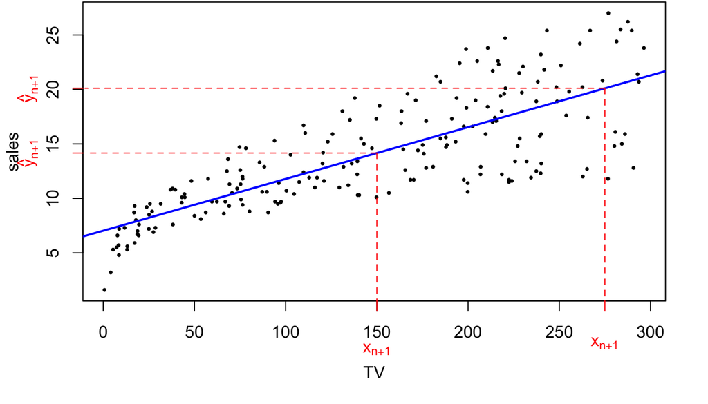

- The further away \(x_{n+1}\) is from \(\bar{x}\), the more uncertain the prediction is.

## Geometrical Interpretation

## Projection

- Recall the vectorial notation:

\[ \begin{aligned} \begin{pmatrix} y_1 \\ \vdots \\ y_n \end{pmatrix} &= \beta_0 \begin{pmatrix} 1 \\ \vdots \\ 1 \end{pmatrix} &&+ \beta_1 \begin{pmatrix} x_1 \\ \vdots \\ x_n \end{pmatrix} &&+ \begin{pmatrix} \epsilon_1 \\ \vdots \\ \epsilon_n \end{pmatrix} \\ ~ \\ \mathbf{y} ~~~\; &= \beta_0 ~~~\mathbb{1} &&+ \beta_1 ~~~\; \mathbf{x} &&+ ~~~ \boldsymbol{\epsilon} \end{aligned} \]

- Define the space \(\mathcal{M}(\mathbf{x}) = \text{span}\{\mathbb{1}, \mathbf{x}\}\)
- Project \(\mathbf{y}\) on \(\mathcal{M}(\mathbf{x})\): \[\text{Proj}_{\mathcal{M}(\mathbf{x})}\mathbf{y} = \underset{\tilde{\mathbf{y}} \in \mathcal{M}(\mathbf{x})}{\operatorname{argmin}}\{\|\mathbf{y} -\tilde{\mathbf{y}}\|^2 \}\]

## Orthogonal Projection

- Project \(\mathbf{y}\) on \(\mathcal{M}(\mathbf{x}) = \text{span}\{\mathbb{1}, \mathbf{x}\}\):

\[ \begin{aligned} \text{Proj}_{\mathcal{M}(\mathbf{x})}\mathbf{y} &= \underset{\tilde{\mathbf{y}} \in \mathcal{M}(\mathbf{x})}{\operatorname{argmin}}\{\|\mathbf{y} -\tilde{\mathbf{y}}\|^2 \}\\ &= \underset{\tilde{\mathbf{y}} = \beta_0 \mathbb{1} + \beta_1 \mathbf{x}\\(\beta_0, \beta_1) \in \mathbb{R}^2}{\operatorname{argmin}}\{\|\mathbf{y} - (\beta_0 \mathbb{1} + \beta_1 \mathbf{x})\|^2 \} \\ &= \underset{\tilde{\mathbf{y}} = \beta_0 \mathbb{1} + \beta_1 \mathbf{x}\\(\beta_0, \beta_1) \in \mathbb{R}^2}{\operatorname{argmin}}\{\sum_{i = 1}^n \left(y_i - (\beta_0 + \beta_1 x_i)\right)^2 \} \\ &= \hat{\mathbf{y}} \\ \end{aligned} \]

- The **OLS** estimator is the **projection** of \(\mathbf{y}\) on \(\mathcal{M}(\mathbf{x})\)

## Geometrical Interpretation

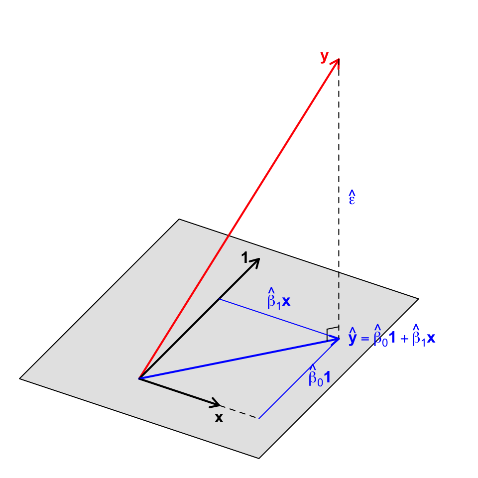

## Accuracy of the Model

## Residual Sum of Squares

- Recall that:

\[ \hat{\sigma}^2 = \frac{1}{n-2} \cdot RSS = \frac{1}{n-2} \sum_{i = 1}^n \hat{\epsilon}_i^2 = \frac{1}{n-2} \|\hat{\epsilon}\|^2 \]

- The RSS measures the **lack of fit** of the model.
- If \(\hat{\mathbf{y}} \approx \mathbf{y}\), the RSS is small.
- **Absolute** lack of fit: measured in the units of \(\mathbf{y}\).

## Variance Decomposition

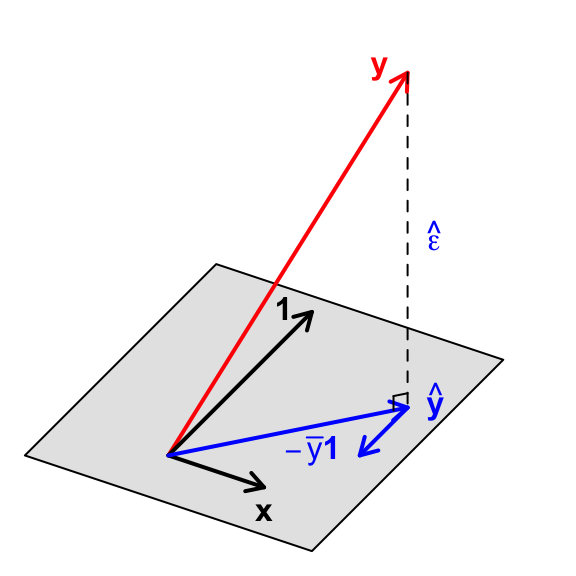

Using Pythagoras’s theorem:

\[ \begin{aligned} \|\mathbf{y} - \bar{y} \mathbb{1}\|^2 &= \|\hat{\mathbf{y}} - \bar{y} \mathbb{1} + \mathbf{y} - \hat{\mathbf{y}}\|^2 \\ &= \|\hat{\mathbf{y}} - \bar{y} \mathbb{1} + \hat{\boldsymbol{\epsilon}}\|^2 \\ &= \|\hat{\mathbf{y}} - \bar{y} \mathbb{1}\|^2 + \|\hat{\boldsymbol{\epsilon}}\|^2 \end{aligned} \]

## Variance Decomposition

\[ \begin{aligned} &\|\mathbf{y} - \bar{y} \mathbb{1}\|^2 &=&&& \|\hat{\mathbf{y}} - \bar{y} \mathbb{1}\|^2 &&+& \|\hat{\boldsymbol{\epsilon}}\|^2 \\ &TSS &=&&& ESS &&+& RSS \end{aligned} \]

- **TSS**: Total Sum of Squares  
  \(\to\) Amount of variability in the response \(\mathbf{y}\) *before* the regression is performed.
- **RSS**: Residual Sum of Squares  
  \(\to\) Amount of variability that is left *after* performing the regression.
- **ESS**: Explained Sum of Squares  
  \(\to\) Amount of variability that is *explained* by the regression.

## \(R^2\) Statistic

\[ R^2 = \frac{ESS}{TSS} = \frac{\|\hat{\mathbf{y}} - \bar{y} \mathbb{1}\|^2}{\|\mathbf{y} - \bar{y} \mathbb{1}\|^2} = 1 - \frac{\|\hat{\epsilon}\|^2}{\|\mathbf{y} - \bar{y} \mathbb{1}\|^2} = 1 - \frac{RSS}{TSS} \]

- \(R^2\) is the **proportion** of variability in \(\mathbf{y}\) that can be explained by the regression.
- \(0 \leq R^2 \leq 1\)
- \(R^2\) = 1: the regression is perfect.  
  \(\to\) \(\mathbf{y} = \hat{\mathbf{y}}\) and \(\mathbf{y}\) is in \(\mathcal{M}(\mathbf{x})\).
- \(R^2\) = 0: the regression is useless.  
  \(\to\) \(\hat{\mathbf{y}} = \bar{y}\mathbb{1}\), the empirical mean is sufficient.

## Advertising

\[ \hat{\sigma}^2 = \frac{1}{n-2} \cdot RSS = 10.62 \quad R^2 = 1 - \frac{RSS}{TSS} = 0.61 \]

## To be continued

## Questions

- Confidence interval for \((\hat{\beta}_0, \hat{\beta}_1, \hat{\sigma}^2)\) ?
- Can we test \(\hat{\beta}_1 = 0\) (i.e. no linear trend) ?
- Assumptions on the moments are not enough.  
  \(\hookrightarrow\) We need assumptions on the *specific distribution* of the \(\epsilon_i\).
- Most common assumption: \(\epsilon_i\) are **Gaussian**.